# Arkaute raw data

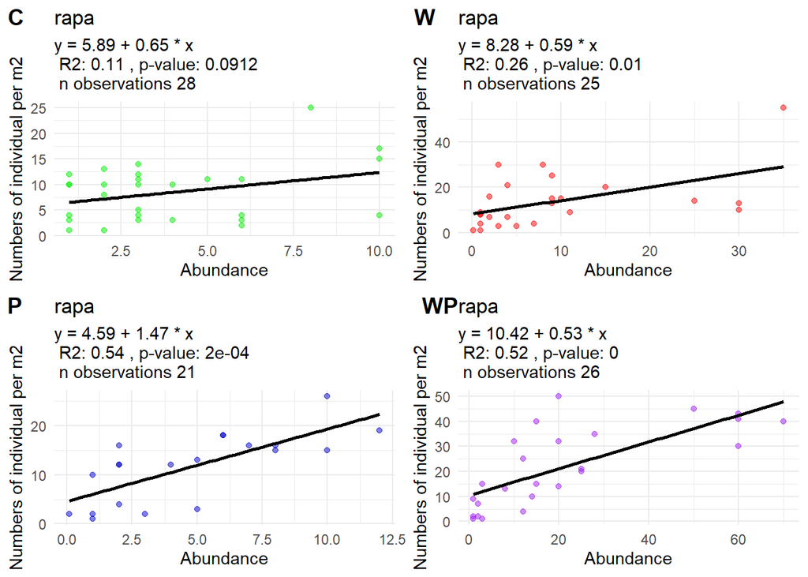

```r
lm_function(nind_2, code_levels_2[14])
```

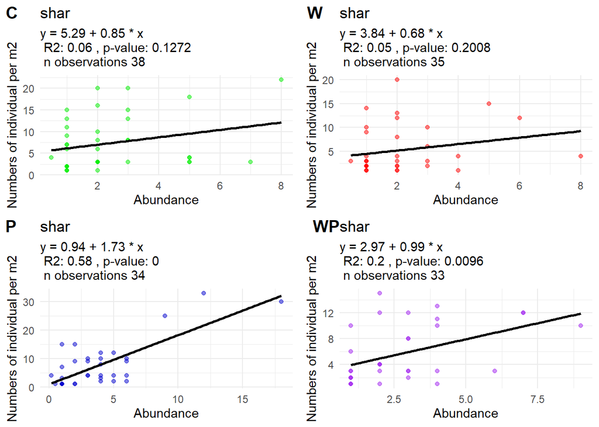

```r
lm_function(nind_2, code_levels_2[15])
```

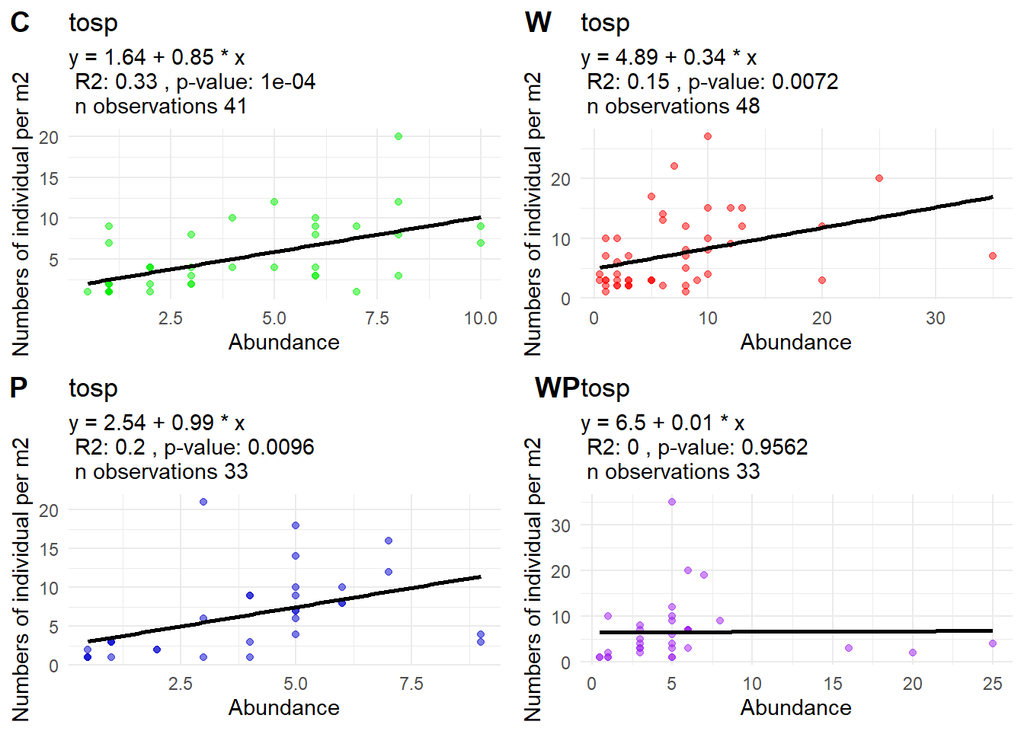

```r
lm_function(nind_2, code_levels_2[16])
```

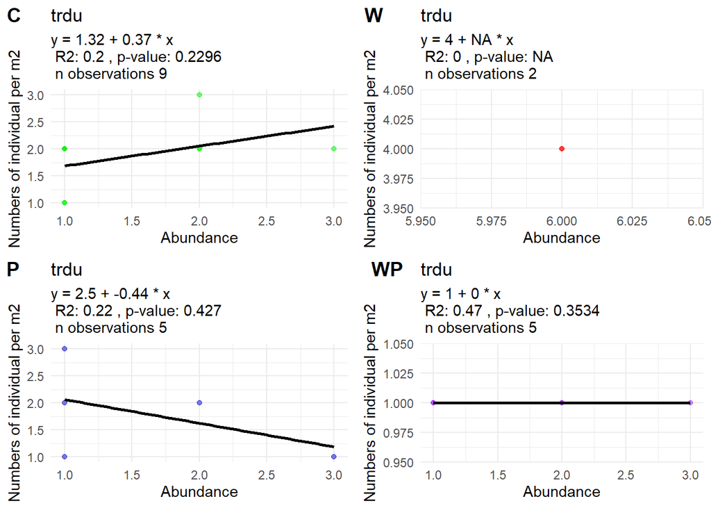

```r
lm_function(nind_2, code_levels_2[17])
```

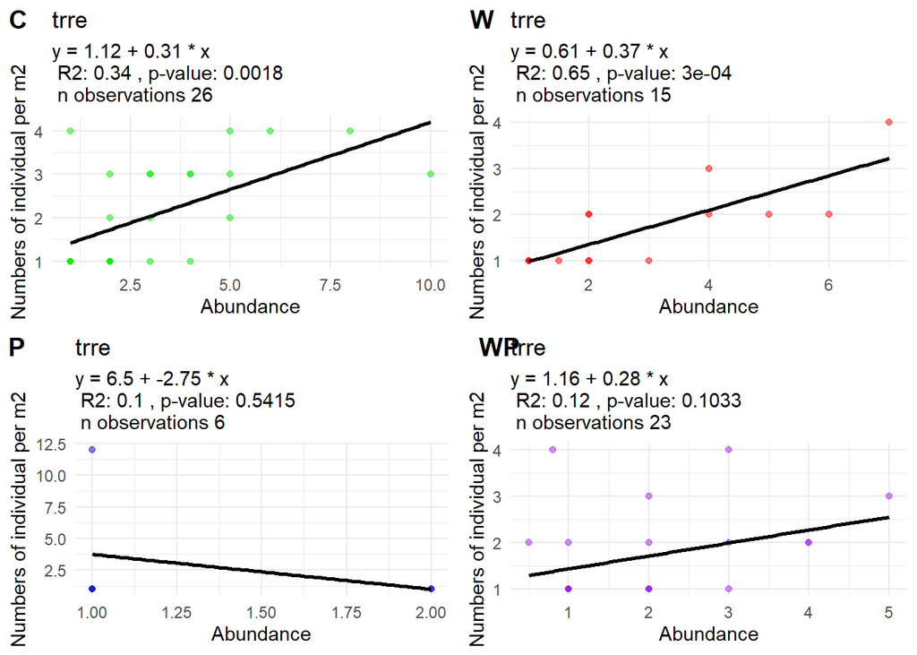

```r
#lm_function(nind_2, code_levels_2[18])
lm_function(nind_2, code_levels_2[19])
```

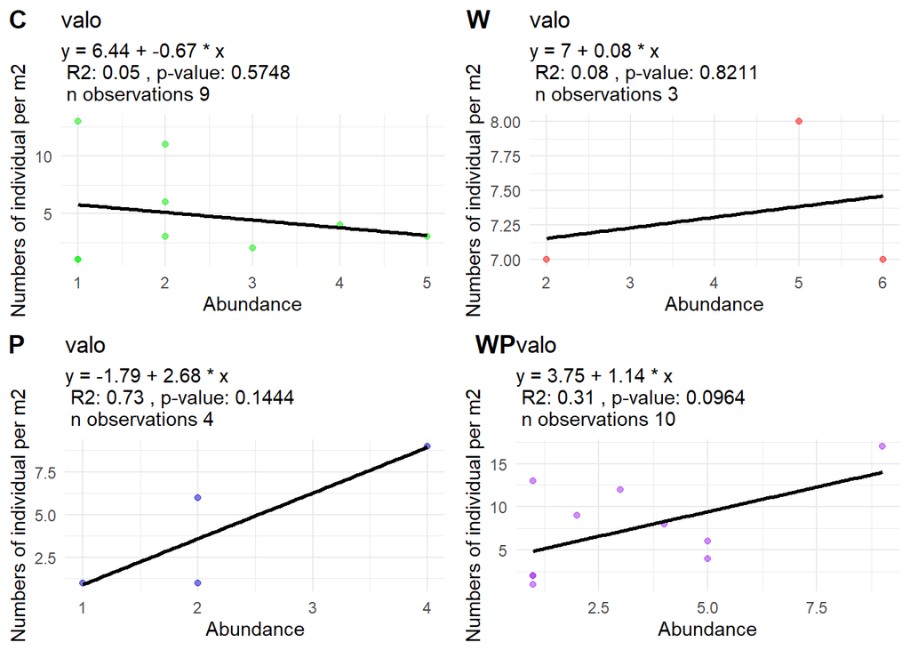

```r
lm_function(nind_2, code_levels_2[20])
```

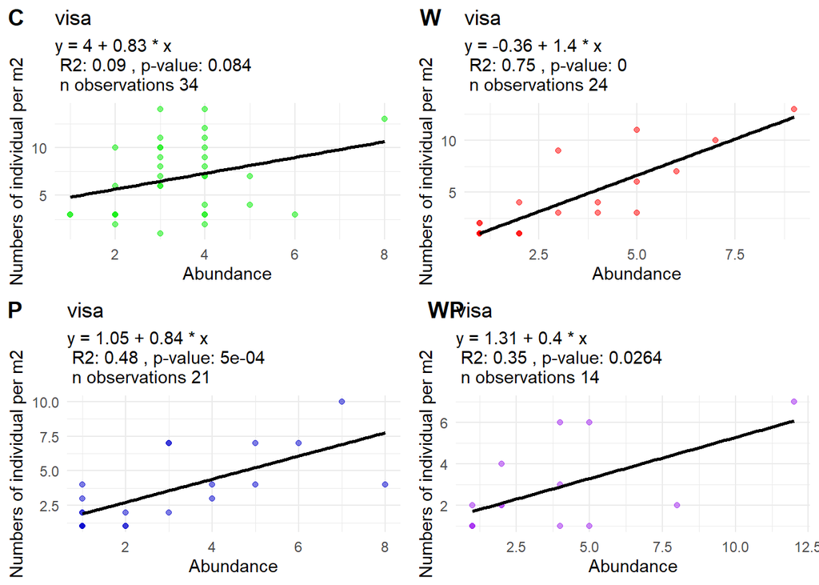

```r
lm_function(nind_2, code_levels_2[21])
```

```r
#lm_function(nind_2, code_levels_2[22])
```

I get the following table:

**Linear model outputs**

| code | intercept | slope | r_squared | p_value | n_observations | n_points_lm | posneg_slope |
| --- | --- | --- | --- | --- | --- | --- | --- |
| apar | 0.5465169 | 3.5170037 | 0.4803653 | 3.0e-07 | NA | 43 | positive |
| asteraceae | 1.5015890 | 0.4039581 | 0.3268168 | 0.0e+00 | NA | 116 | positive |
| bepe | 1.1098790 | 0.2911842 | 0.1905374 | 6.3e-06 | NA | 99 | positive |
| cegl | 0.7000097 | 1.6814971 | 0.6145286 | 0.0e+00 | NA | 82 | positive |
| gedi | 1.5314722 | 0.6089773 | 0.4546904 | 0.0e+00 | NA | 132 | positive |
| gemo | 1.1035169 | 0.6221382 | 0.4939978 | 1.0e-07 | NA | 45 | positive |

#### 2.4.4 Calculation of number of individuals per square metre

The resulting table is integrated with the biomass database so we can calculate the number of individuals per m$^2$ for all rows.

```r
flora_biomass_lm <- merge(flora_biomass_raw, nind_lm_species_2)

flora_biomass_lm$nind_m2 <-
  flora_biomass_lm$intercept + flora_biomass_lm$abundance * flora_biomass_lm$slope
```

Since there are some species for which its intercept is negative, the lm consider that nind_m2 < 0 when abundance = 0, and that cannot be the case. This happens for 3 species. We can either delete these species or make *this “dummy” correction by saying that if nind_m2 < 0 , then nind_m2 = 1.*

```r
#
# Dummy correction ?????????????????????????????????????
flora_biomass_lm <- flora_biomass_lm %>%
  mutate(nind_m2 = ifelse(nind_m2 < 0, 1, nind_m2))
```

#### 2.4.5 Calculation of biomass at species level +

Calculation of species biomass (biomass_s) per square meter by multiplying biomass at individual (biomass_i) level by the number of individuals per square meter (nind_m2)

```r
flora_biomass_lm$biomass_s <- flora_biomass_lm$biomass_i * flora_biomass_lm$nind_m2
```

Then, I join the “lonely” species biomass database and the linear model species database.

```r
#Putting together lm species and one ind species
flora_biomass <- bind_rows(flora_biomass_oneind, flora_biomass_lm)
```

#### 2.4.6 Outliers of biomass_s

At this point, it is worth considering the removal of outlier for biomass_s. To reach this information we have: 1) Used abundance data gathered from the field by direct observations 2) Used morphological measurements taken in the field in the application of a biomass equation 3) Used the available data of number of individuals / m2 and species that was gathered in the field by visual estimation 4) Used a linear model to estimate the number of individuals per m2 for all species, samplings and plots. 5) Calculated the biomass at species level by biomass_i * nind_m2.

So, here there are many calculations that might had led to error accumulation.

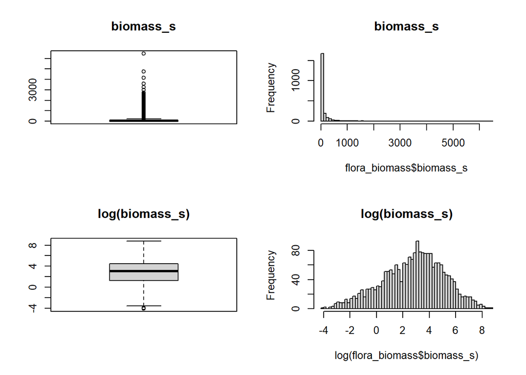

```r
par(mfrow = c(2,2))
boxplot(flora_biomass$biomass_s, main = "biomass_s")
hist(flora_biomass$biomass_s, breaks = 50, main = "biomass_s")

#With log transformation
boxplot(log(flora_biomass$biomass_s), main = "log(biomass_s)")
hist(log(flora_biomass$biomass_s), breaks = 50, main = "log(biomass_s)")
```

```r
# Step 1: Calculate IQR for log-transformed biomass_s
Q1 <- quantile(log(flora_biomass$biomass_s), 0.25, na.rm = TRUE)
Q3 <- quantile(log(flora_biomass$biomass_s), 0.75, na.rm = TRUE)
IQR <- Q3 - Q1

# Step 2: Remove outliers
flora_biomass_clean <- flora_biomass %>%
  filter(log(biomass_s) >= Q1 - 1.5 * IQR & log(biomass_s) <= Q3 + 1.5 * IQR)
```

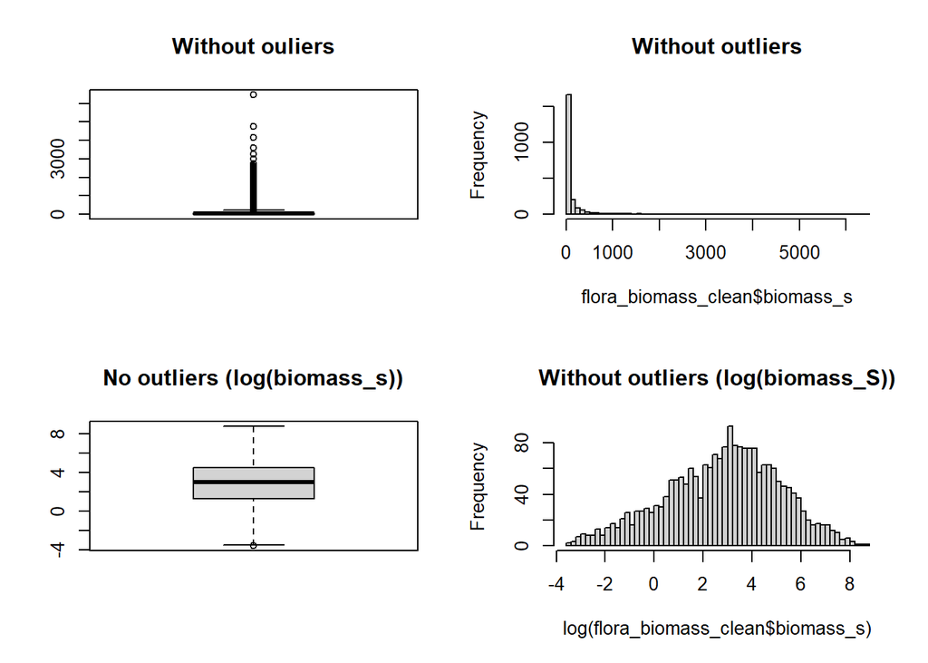

```r
# View the cleaned data
par(mfrow = c(2,2))
# Without ouliers
boxplot(flora_biomass_clean$biomass_s, main = "Without ouliers")
hist(flora_biomass_clean$biomass_s, breaks = 50, main = "Without outliers")

# Without ouliers + logtrasnform
boxplot(log(flora_biomass_clean$biomass_s), main = "No outliers (log(biomass_s))")
hist(log(flora_biomass_clean$biomass_s), breaks = 50, main = "Without outliers (log(biomass_S))")
```

There is almost no difference. Mark proposes to work on biomass as log(biomass) since it is the most common way of working in ecology

### 2.5 Biomass at community levels

Calculation of total biomasss (biomass_community) by summing all biomass at species level per square meter (biomass_s).

```r
flora_biomass <- flora_biomass %>%
  group_by(plot, sampling, treatment) %>%
  mutate(biomass_community =  sum(biomass_s, na.rm = TRUE)) %>%
  ungroup()

flora_biomass_clean <- flora_biomass_clean %>%
  group_by(plot, sampling, treatment) %>%
  mutate(biomass_community =  sum(biomass_s, na.rm = TRUE)) %>%
  ungroup()
```